# COMP47590 Assignment 2: Come Fly With Me

Xuefei Jiang (22200056)

Puru Chaudhary(22200581)

Nikhil . (22200728)

This assignment aims to train a simple agent to control the behaviour of the bird in the game of Flappy Bird.

We've checked that, once the all packages are installed correctly, the notebook can be executed on both MacOS or Windows.

There are two discrete **actions** in this environment:

- none (0)
- flap (1)

**Reward** is awarded as:

- +0.1 - every frame it stays alive
- +1.0 - successfully passing a pipe
- -1.0 - dying

And the environment offers two **observation** types.

1. A vector based observation where the elements in the vector are:
- the last pipe's horizontal position
- the last top pipe's vertical position
- the last bottom pipe's vertical position
- the next pipe's horizontal position
- the next top pipe's vertical position
- the next bottom pipe's vertical position
- the next next pipe's horizontal position
- the next next top pipe's vertical position
- the next next bottom pipe's vertical position
- player's vertical position
- player's vertical velocity
- player's rotation
1. An RGB image based observation of a screenshot of the game (not including score) of size 288 X 512 pixels.

## Presentation of best agent

In this report, we will explore two types of agents in both vector observation and image stack observation, which is four agents in total:

1. DQN agent w.r.t. vector observatioin;
2. PPO agent w.r.t. vector observatioin;
3. DQN agent w.r.t. image stack observation;
4. PPO agent w.r.t. image stack observation;

Each agent has been trained for 5 million steps. The best of them is **DQN agent w.r.t. image stack observation**. As the following image shows, the trained agent fly for quite a long time. You can also watch it by opening best.gif and best.mp4.

```python
from IPython.display import Image
Image(url='best.gif')
```

[figure not shown]

```python
import gymnasium as gym
import flappy_bird_gymnasium
import stable_baselines3 as sb3
import time
import imageio

import pandas as pd # For data frames and data frame manipulation
pd.set_option('display.max_rows', 100)
pd.set_option('display.max_columns', 100)
pd.set_option('display.width', 1000)
import numpy as np # For general  numeric operations

import matplotlib.pyplot as plt
%matplotlib inline
```

## 1. Vector Based Observation

### 1.1 Create and explore the environment

Create the environment.

```python
env = gym.make('FlappyBird-v0')
```

Explore the action space.

```python
env.action_space
```

```
Discrete(2)
```

Explore the observation space.

```python
env.observation_space
```

```
Box(-inf, inf, (12,), float64)
```

Play an episode of the environment using random actions.

```python
obs, _ = env.reset()
frames = []
while True:
    action = env.action_space.sample()
    obs, reward, terminated, done, info = env.step(action)

    # Rendering the game:
    env.render()
    time.sleep(1 / 30)  # FPS

    # Checking if the player is still alive
    if terminated:
        break
```

### 1.2 Train and test DQN agent

In this section, we train and test the DQN agent in this environment.

#### Training

Create the training environment and limit the max number of steps in an episode so that the agent won't run forever.

```python
# create training environment
train_env = gym.make("FlappyBird-v0")
# limit the max number of steps in an episode so that the bird won't fly forever
train_env = gym.wrappers.TimeLimit(train_env, max_episode_steps=3000)
```

Create the agent. A vanilla neural network is power enough for the vector observation so we use MlpPolicy.

```python
log_dir = "./dqn_vector_agent_log"

parameters = {
    "learning_rate": 0.0001,
    "buffer_size": 50000,
    "learning_starts": 5000,
    "batch_size":128,
    "gamma": 0.99,
    "exploration_fraction": 0.9,
    "target_update_interval": 1000,
    "exploration_initial_eps": 0.1,
    "exploration_final_eps": 0.0001,
}

# create agent
agent = sb3.DQN("MlpPolicy", train_env, tensorboard_log=log_dir, **parameters)
```

Examine the agent network architectures.

```python
print(agent.policy)
```

```
DQNPolicy(
  (q_net): QNetwork(
    (features_extractor): FlattenExtractor(
      (flatten): Flatten(start_dim=1, end_dim=-1)
    )
    (q_net): Sequential(
      (0): Linear(in_features=12, out_features=64, bias=True)
      (1): ReLU()
      (2): Linear(in_features=64, out_features=64, bias=True)
      (3): ReLU()
      (4): Linear(in_features=64, out_features=2, bias=True)
    )
  )
  (q_net_target): QNetwork(
    (features_extractor): FlattenExtractor(
      (flatten): Flatten(start_dim=1, end_dim=-1)
    )
    (q_net): Sequential(
      (0): Linear(in_features=12, out_features=64, bias=True)
      (1): ReLU()
      (2): Linear(in_features=64, out_features=64, bias=True)
      (3): ReLU()
      (4): Linear(in_features=64, out_features=2, bias=True)
    )
  )
)
```

For this simple flappy bird application, the default network architecture, so we don't need to customized the network.

Create the environment for evaluation.

```python
# create evaluation environment
eval_env = gym.make("FlappyBird-v0")
eval_env = gym.wrappers.TimeLimit(eval_env, max_episode_steps=3000)
# create evaluation callback
eval_callback = sb3.common.callbacks.EvalCallback(
    eval_env,
    n_eval_episodes=10,
    eval_freq=5000,
    log_path=log_dir,
    best_model_save_path=log_dir,
    render=False,
)
```

Connect to the tensorboard log using **TensorBoard** from the command line to view training progress:

`tensorboard --logdir ./dqn_vector_agent_log/`

Then open TensorBoard in a browser, typically located at:

`http://localhost:6006/`

We're only training for 10K steps in this notebook to show the code works correctly. Actually, we trained the agent for 5 million steps on a linux server. Please refer to the train_scripts folder for full training on 5 million timesteps.

```python
agent.learn(total_timesteps=10000, callback=eval_callback)
```

```
Eval num_timesteps=5000, episode_reward=2.10 +/- 0.00
Episode length: 32.00 +/- 0.00
New best mean reward!
Eval num_timesteps=10000, episode_reward=9.23 +/- 0.28
Episode length: 103.30 +/- 2.83
New best mean reward!
```

```
<stable_baselines3.dqn.dqn.DQN at 0x7fc6c4b51f10>
```

The following cell plots the cumulative returns during the training process of 5 million steps. You can find the raw data in saved folder.

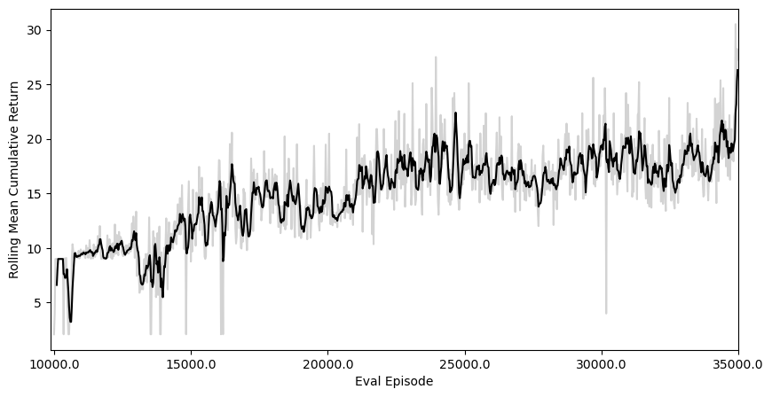

```python
eval_log_path = 'saved/dqn_vector_agent_log/'
evaluation_log = np.load(eval_log_path + 'evaluations.npz')
evaluation_log_df = pd.DataFrame({item: [np.mean(ep) for ep in evaluation_log[item]] for item in evaluation_log.files})
ax = evaluation_log_df.loc[0:len(evaluation_log_df), 'results'].plot(color = 'lightgray', xlim = [-5, len(evaluation_log_df)], figsize = (10,5))
evaluation_log_df['results'].rolling(5).mean().plot(color = 'black', xlim = [-5, len(evaluation_log_df)])
ax.set_xticklabels(evaluation_log_df['timesteps'])
ax.set_xlabel("Eval Episode")
plt.ylabel("Rolling Mean Cumulative Return")
plt.show()
```

As the training progresses, the cumulative return increases, demonstrating a continuous improvement in the agent's performance. However, as we will see later, the results are not as good as others. This is due to the fact that, compared with image stack observation, vector observation cannot provide information for the agent to make decisioins.

#### Deploy and Testing

Here, we deploy and test the fullying trained (5 million steps) agent. You can find the snapshot in saved folder.

```python
# create test environment
test_env = gym.make("FlappyBird-v0")
# limit the max number of steps in an episode so that the bird won't fly forever
test_env = gym.wrappers.TimeLimit(test_env, max_episode_steps=3000)
```

```python
# load fully trained (5,000,000 steps) agent
agent = sb3.DQN.load("saved/dqn_vector_agent_log/best_model.zip")
```

```python
# put agent into test environment
agent.set_env(test_env)
```

```python
mean_reward, std_reward = sb3.common.evaluation.evaluate_policy(
    agent, test_env, n_eval_episodes=30, render=False
)
print("Mean Reward: {} +/- {}".format(mean_reward, std_reward))
```

```
Mean Reward: 19.226666934788227 +/- 7.694757324374842
```

Render the agent. You can repeat by running the following cell for multiple times.

```python
obs, _ = test_env.reset()
agent.set_env(test_env)
terminate = False
done = False
while not (terminate or done):
    action, _ = agent.predict(obs, deterministic = True)
    obs, reward, terminate, done, info = test_env.step(action)
    test_env.render()
    time.sleep(1 / 30)  # FPS
```

### 1.3 Train and test PPO agent

In this section, we train and test the PPO agent in this environment.

#### Training

Create the training environment and limit the max number of steps in an episode so that the agent won't run forever.

```python
# create training environment
train_env = gym.make("FlappyBird-v0")
# limit the max number of steps in an episode so that the bird won't fly forever
train_env = gym.wrappers.TimeLimit(train_env, max_episode_steps=3000)
```

Create the agent. A vanilla neural network is power enough for the vector observation so we use MlpPolicy.

```python
log_dir = "./ppo_vector_agent_log"

# create agent
agent = sb3.ppo.PPO(
    "MlpPolicy",
    train_env,
    learning_rate=3e-5,
    n_steps=512,
    ent_coef=0.001,
    batch_size=128,
    gae_lambda=0.9,
    n_epochs=20,
    clip_range=0.4,
    policy_kwargs={"log_std_init": -2, "ortho_init": False},
    tensorboard_log=log_dir,
)
```

Examine the agent network architectures.

```python
print(agent.policy)
```

```
ActorCriticPolicy(
  (features_extractor): FlattenExtractor(
    (flatten): Flatten(start_dim=1, end_dim=-1)
  )
  (pi_features_extractor): FlattenExtractor(
    (flatten): Flatten(start_dim=1, end_dim=-1)
  )
  (vf_features_extractor): FlattenExtractor(
    (flatten): Flatten(start_dim=1, end_dim=-1)
  )
  (mlp_extractor): MlpExtractor(
    (policy_net): Sequential(
      (0): Linear(in_features=12, out_features=64, bias=True)
      (1): Tanh()
      (2): Linear(in_features=64, out_features=64, bias=True)
      (3): Tanh()
    )
    (value_net): Sequential(
      (0): Linear(in_features=12, out_features=64, bias=True)
      (1): Tanh()
      (2): Linear(in_features=64, out_features=64, bias=True)
      (3): Tanh()
    )
  )
  (action_net): Linear(in_features=64, out_features=2, bias=True)
  (value_net): Linear(in_features=64, out_features=1, bias=True)
)
```

For this simple flappy bird application, the default network architecture, so we don't need to customized the network.

Create the environment for evaluation.

```python
# create evaluation environment
eval_env = gym.make("FlappyBird-v0")
eval_env = gym.wrappers.TimeLimit(eval_env, max_episode_steps=3000)
# create evaluation callback
eval_callback = sb3.common.callbacks.EvalCallback(
    eval_env,
    n_eval_episodes=10,
    eval_freq=5000,
    log_path=log_dir,
    best_model_save_path=log_dir,
    render=False,
)
```

Connect to the tensorboard log using **TensorBoard** from the command line to view training progress:

`tensorboard --logdir ./ppo_vector_agent_log/`

Then open TensorBoard in a browser, typically located at:

`http://localhost:6006/`

We're only training for 10K steps in this notebook to show the code works correctly. Actually, we trained the agent for 5 million steps on a linux server. Please refer to the train_scripts folder for full training on 5 million timesteps.

```python
agent.learn(total_timesteps=10000, callback=eval_callback)
```

```
Eval num_timesteps=5000, episode_reward=2.10 +/- 0.00
Episode length: 32.00 +/- 0.00
New best mean reward!
Eval num_timesteps=10000, episode_reward=9.00 +/- 0.00
Episode length: 101.00 +/- 0.00
New best mean reward!
```

```
<stable_baselines3.ppo.ppo.PPO at 0x7fc6c78f6d60>
```

The following cell plots the cumulative returns during the training process of 5 million steps. You can find the raw data in saved folder.

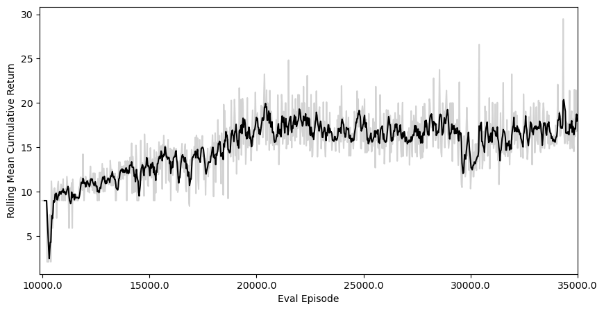

```python
eval_log_path = 'saved/ppo_vector_agent_log/'
evaluation_log = np.load(eval_log_path + 'evaluations.npz')
evaluation_log_df = pd.DataFrame({item: [np.mean(ep) for ep in evaluation_log[item]] for item in evaluation_log.files})
ax = evaluation_log_df.loc[0:len(evaluation_log_df), 'results'].plot(color = 'lightgray', xlim = [-5, len(evaluation_log_df)], figsize = (10,5))
evaluation_log_df['results'].rolling(5).mean().plot(color = 'black', xlim = [-5, len(evaluation_log_df)])
ax.set_xticklabels(evaluation_log_df['timesteps'])
ax.set_xlabel("Eval Episode")
plt.ylabel("Rolling Mean Cumulative Return")
plt.show()
```

We can draw the similar conclusion as in DQN agent w.r.t. vector observation.

#### Deploy and Testing

Here, we deploy and test the fullying trained (5 million steps) agent. You can find the snapshot in saved folder.

```python
# create test environment
test_env = gym.make("FlappyBird-v0")
# limit the max number of steps in an episode so that the bird won't fly forever
test_env = gym.wrappers.TimeLimit(test_env, max_episode_steps=3000)
```

```python
# load fully trained (5,000,000 steps) agent
agent = sb3.PPO.load("saved/ppo_vector_agent_log/best_model.zip")
```

```python
# put agent into test environment
agent.set_env(test_env)
```

```python
mean_reward, std_reward = sb3.common.evaluation.evaluate_policy(
    agent, test_env, n_eval_episodes=30, render=False
)
print("Mean Reward: {} +/- {}".format(mean_reward, std_reward))
```

```
Mean Reward: 17.516666914771 +/- 7.014845451510857
```

Render the agent. You can repeat by running the following cell for multiple times.

```python
obs, _ = test_env.reset()
agent.set_env(test_env)
terminate = False
done = False
while not (terminate or done):
    action, _ = agent.predict(obs, deterministic = True)
    obs, reward, terminate, done, info = test_env.step(action)
    test_env.render()
    time.sleep(1 / 30)  # FPS
```

## 2. Screenshot Observation

### 2.1 Create and explore the environment

Create the environment.

```python
env = gym.make("FlappyBird-rgb-v0")
```

Explore the action space.

```python
env.action_space
```

```
Discrete(2)
```

Explore the observation space.

```python
env.observation_space
```

```
Box(0.0, 255.0, (288, 512, 3), float32)
```

Play an episode of the environment using random actions.

```python
obs, _ = env.reset()
frames = []
while True:
    action = env.action_space.sample()
    obs, reward, terminated, done, info = env.step(action)

    # Rendering the game:
    env.render()
    time.sleep(1 / 30)  # FPS

    # Checking if the player is still alive
    if terminated:
        break
```

### 2.2 Train and test DQN agent

In this section, we train and test the DQN agent in this environment.

#### Training

Create the training environment and limit the max number of steps in an episode so that the agent won't run forever.

Resize the observation to speed up image processing.

Use stacks of screenshots (k = 4 here) provide enough information to capture the state.

```python
# create training environment
train_env = gym.make("FlappyBird-rgb-v0")
# limit the max number of steps in an episode so that the bird won't fly forever
train_env = gym.wrappers.TimeLimit(train_env, max_episode_steps=3000)
# resize observation to (64, 128)
train_env = gym.wrappers.resize_observation.ResizeObservation(train_env, (64, 128))
train_env = gym.wrappers.gray_scale_observation.GrayScaleObservation(
    train_env, keep_dim=True
)
train_env = sb3.common.vec_env.DummyVecEnv([lambda: train_env])
train_env = sb3.common.vec_env.VecFrameStack(train_env, n_stack=4)
```

Create the agent. Compared with vanilla neural network, convolutional neural network is more suitable to process images. So CnnPolicy is used here.

```python
log_dir = "./dqn_image_stack_agent_log"

parameters = {
    "learning_rate": 0.0001,
    "buffer_size": 50000,
    "learning_starts": 5000,
    "batch_size": 128,
    "gamma": 0.99,
    "exploration_fraction": 0.9,
    "target_update_interval": 1000,
    "exploration_initial_eps": 0.1,
    "exploration_final_eps": 0.0001,
}

# create agent
agent = sb3.DQN("CnnPolicy", train_env, tensorboard_log=log_dir, **parameters)
```

Examine the agent network architectures.

```python
print(agent.policy)
```

```
CnnPolicy(
  (q_net): QNetwork(
    (features_extractor): NatureCNN(
      (cnn): Sequential(
        (0): Conv2d(4, 32, kernel_size=(8, 8), stride=(4, 4))
        (1): ReLU()
        (2): Conv2d(32, 64, kernel_size=(4, 4), stride=(2, 2))
        (3): ReLU()
        (4): Conv2d(64, 64, kernel_size=(3, 3), stride=(1, 1))
        (5): ReLU()
        (6): Flatten(start_dim=1, end_dim=-1)
      )
      (linear): Sequential(
        (0): Linear(in_features=3072, out_features=512, bias=True)
        (1): ReLU()
      )
    )
    (q_net): Sequential(
      (0): Linear(in_features=512, out_features=2, bias=True)
    )
  )
  (q_net_target): QNetwork(
    (features_extractor): NatureCNN(
      (cnn): Sequential(
        (0): Conv2d(4, 32, kernel_size=(8, 8), stride=(4, 4))
        (1): ReLU()
        (2): Conv2d(32, 64, kernel_size=(4, 4), stride=(2, 2))
        (3): ReLU()
        (4): Conv2d(64, 64, kernel_size=(3, 3), stride=(1, 1))
        (5): ReLU()
        (6): Flatten(start_dim=1, end_dim=-1)
      )
      (linear): Sequential(
        (0): Linear(in_features=3072, out_features=512, bias=True)
        (1): ReLU()
      )
    )
    (q_net): Sequential(
      (0): Linear(in_features=512, out_features=2, bias=True)
    )
  )
)
```

For this simple flappy bird application, the default network architecture, so we don't need to customized the network.

Create the environment for evaluation.

```python
# create evaluation environment
eval_env = gym.make("FlappyBird-rgb-v0")
eval_env = gym.wrappers.TimeLimit(eval_env, max_episode_steps=3000)
eval_env = gym.wrappers.resize_observation.ResizeObservation(eval_env, (64, 128))
eval_env = gym.wrappers.gray_scale_observation.GrayScaleObservation(
    eval_env, keep_dim=True
)
eval_env = sb3.common.vec_env.DummyVecEnv([lambda: eval_env])
eval_env = sb3.common.vec_env.VecFrameStack(eval_env, n_stack=4)
# create evaluation callback
eval_callback = sb3.common.callbacks.EvalCallback(
    eval_env,
    n_eval_episodes=10,
    eval_freq=5000,
    log_path=log_dir,
    best_model_save_path=log_dir,
    render=False,
)
```

Connect to the tensorboard log using **TensorBoard** from the command line to view training progress:

`tensorboard --logdir ./dqn_image_stack_agent_log/`

Then open TensorBoard in a browser, typically located at:

`http://localhost:6006/`

We're only training for 10K steps in this notebook to show the code works correctly. Actually, we trained the agent for 5 million steps on a linux server. Please refer to the train_scripts folder for full training on 5 million timesteps.

```python
agent.learn(total_timesteps=10000, callback=eval_callback)
```

```
Eval num_timesteps=5000, episode_reward=9.00 +/- 0.00
Episode length: 101.00 +/- 0.00
New best mean reward!
Eval num_timesteps=10000, episode_reward=9.00 +/- 0.00
Episode length: 101.00 +/- 0.00
```

```
<stable_baselines3.dqn.dqn.DQN at 0x7fc6c85bea60>
```

The following cell plots the cumulative returns during the training process of 5 million steps. You can find the raw data in saved folder.

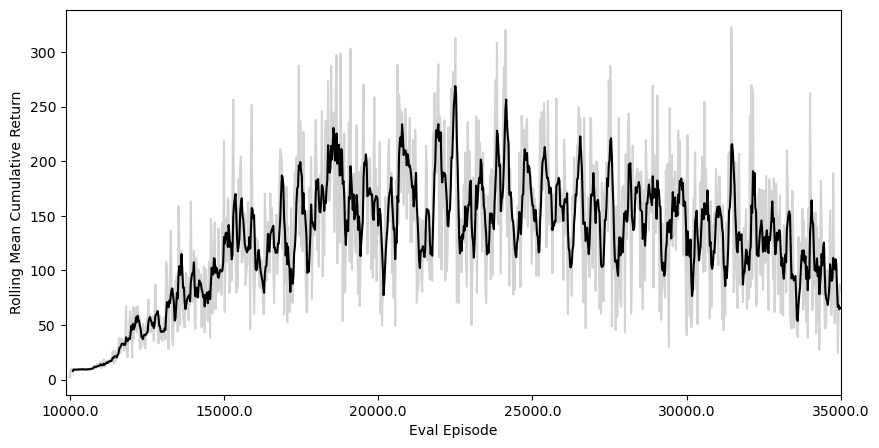

```python
eval_log_path = 'saved/dqn_image_stack_agent_log/'
evaluation_log = np.load(eval_log_path + 'evaluations.npz')
evaluation_log_df = pd.DataFrame({item: [np.mean(ep) for ep in evaluation_log[item]] for item in evaluation_log.files})
ax = evaluation_log_df.loc[0:len(evaluation_log_df), 'results'].plot(color = 'lightgray', xlim = [-5, len(evaluation_log_df)], figsize = (10,5))
evaluation_log_df['results'].rolling(5).mean().plot(color = 'black', xlim = [-5, len(evaluation_log_df)])
ax.set_xticklabels(evaluation_log_df['timesteps'])
ax.set_xlabel("Eval Episode")
plt.ylabel("Rolling Mean Cumulative Return")
plt.show()
```

The DQN agent w.r.t. image stack observation performs much better than vector observation because image stacks (k=4) provides much more information for the agent to make decisions. It should be noted that the cumulative reture first increases and then decreases, which mean it is not always good to train the agent for a long time.

#### Deploy and Testing

Here, we deploy and test the fullying trained (5 million steps) agent. You can find the snapshot in saved folder.

```python
# create test environment
test_env = gym.make("FlappyBird-rgb-v0", render_mode='human')
# limit the max number of steps in an episode so that the bird won't fly forever
test_env = gym.wrappers.TimeLimit(test_env, max_episode_steps=3000)
# resize observation to (64, 128)
test_env = gym.wrappers.resize_observation.ResizeObservation(test_env, (64, 128))
test_env = gym.wrappers.gray_scale_observation.GrayScaleObservation(
    test_env, keep_dim=True
)
test_env = sb3.common.vec_env.DummyVecEnv([lambda: test_env])
test_env = sb3.common.vec_env.VecFrameStack(test_env, n_stack=4)
```

```python
# load fully trained (5,000,000 steps) agent
agent = sb3.DQN.load("saved/dqn_image_stack_agent_log/best_model.zip")
```

```python
# put agent into test environment
agent.set_env(test_env)
```

```python
mean_reward, std_reward = sb3.common.evaluation.evaluate_policy(
    agent, test_env, n_eval_episodes=30, render=False
)
print("Mean Reward: {} +/- {}".format(mean_reward, std_reward))
```

```
Mean Reward: 231.0266694088777 +/- 133.83539781057965
```

Render the agent. You can repeat by running the following cell for multiple times.

```python
obs = test_env.reset()
agent.set_env(test_env)
terminate = False
done = False
while not terminate:
    action, _ = agent.predict(obs, deterministic=True)
    obs, reward, terminate, info = test_env.step(action)
    test_env.render()
    time.sleep(1 / 30)  # FPS
```

### 2.3 Train and test PPO agent

In this section, we train and test the PPO agent in this environment.

#### Training

Create the training environment and limit the max number of steps in an episode so that the agent won't run forever.

Resize the observation to speed up image processing.

Use stacks of screenshots (k = 4 here) provide enough information to capture the state.

```python
# create training environment
train_env = gym.make("FlappyBird-rgb-v0")
# limit the max number of steps in an episode so that the bird won't fly forever
train_env = gym.wrappers.TimeLimit(train_env, max_episode_steps=3000)
# resize observation to (64, 128)
train_env = gym.wrappers.resize_observation.ResizeObservation(train_env, (64, 128))
train_env = gym.wrappers.gray_scale_observation.GrayScaleObservation(
    train_env, keep_dim=True
)
train_env = sb3.common.vec_env.DummyVecEnv([lambda: train_env])
train_env = sb3.common.vec_env.VecFrameStack(train_env, n_stack=4)
```

Create the agent. Compared with vanilla neural network, convolutional neural network is more suitable to process images. So CnnPolicy is used here.

```python
log_dir = "./ppo_image_stack_agent_log"

# create agent
agent = sb3.ppo.PPO(
    "CnnPolicy",
    train_env,
    learning_rate=3e-5,
    n_steps=512,
    ent_coef=0.001,
    batch_size=128,
    gae_lambda=0.9,
    n_epochs=20,
    clip_range=0.4,
    policy_kwargs={"log_std_init": -2, "ortho_init": False},
    tensorboard_log=log_dir,
)
```

Examine the agent network architectures.

```python
print(agent.policy)
```

```
ActorCriticCnnPolicy(
  (features_extractor): NatureCNN(
    (cnn): Sequential(
      (0): Conv2d(4, 32, kernel_size=(8, 8), stride=(4, 4))
      (1): ReLU()
      (2): Conv2d(32, 64, kernel_size=(4, 4), stride=(2, 2))
      (3): ReLU()
      (4): Conv2d(64, 64, kernel_size=(3, 3), stride=(1, 1))
      (5): ReLU()
      (6): Flatten(start_dim=1, end_dim=-1)
    )
    (linear): Sequential(
      (0): Linear(in_features=3072, out_features=512, bias=True)
      (1): ReLU()
    )
  )
  (pi_features_extractor): NatureCNN(
    (cnn): Sequential(
      (0): Conv2d(4, 32, kernel_size=(8, 8), stride=(4, 4))
      (1): ReLU()
      (2): Conv2d(32, 64, kernel_size=(4, 4), stride=(2, 2))
      (3): ReLU()
      (4): Conv2d(64, 64, kernel_size=(3, 3), stride=(1, 1))
      (5): ReLU()
      (6): Flatten(start_dim=1, end_dim=-1)
    )
    (linear): Sequential(
      (0): Linear(in_features=3072, out_features=512, bias=True)
      (1): ReLU()
    )
  )
  (vf_features_extractor): NatureCNN(
    (cnn): Sequential(
      (0): Conv2d(4, 32, kernel_size=(8, 8), stride=(4, 4))
      (1): ReLU()
      (2): Conv2d(32, 64, kernel_size=(4, 4), stride=(2, 2))
      (3): ReLU()
      (4): Conv2d(64, 64, kernel_size=(3, 3), stride=(1, 1))
      (5): ReLU()
      (6): Flatten(start_dim=1, end_dim=-1)
    )
    (linear): Sequential(
      (0): Linear(in_features=3072, out_features=512, bias=True)
      (1): ReLU()
    )
  )
  (mlp_extractor): MlpExtractor(
    (policy_net): Sequential()
    (value_net): Sequential()
  )
  (action_net): Linear(in_features=512, out_features=2, bias=True)
  (value_net): Linear(in_features=512, out_features=1, bias=True)
)
```

For this simple flappy bird application, the default network architecture, so we don't need to customized the network.

Create the environment for evaluation.

```python
# create evaluation environment
eval_env = gym.make("FlappyBird-rgb-v0")
eval_env = gym.wrappers.TimeLimit(eval_env, max_episode_steps=3000)
eval_env = gym.wrappers.resize_observation.ResizeObservation(eval_env, (64, 128))
eval_env = gym.wrappers.gray_scale_observation.GrayScaleObservation(
    eval_env, keep_dim=True
)
eval_env = sb3.common.vec_env.DummyVecEnv([lambda: eval_env])
eval_env = sb3.common.vec_env.VecFrameStack(eval_env, n_stack=4)
# create evaluation callback
eval_callback = sb3.common.callbacks.EvalCallback(
    eval_env,
    n_eval_episodes=10,
    eval_freq=5000,
    log_path=log_dir,
    best_model_save_path=log_dir,
    render=False,
)
```

Connect to the tensorboard log using **TensorBoard** from the command line to view training progress:

`tensorboard --logdir ./ppo_image_stack_agent_log/`

Then open TensorBoard in a browser, typically located at:

`http://localhost:6006/`

We're only training for 10K steps in this notebook to show the code works correctly. Actually, we trained the agent for 5 million steps on a linux server. Please refer to the train_scripts folder for full training on 5 million timesteps.

```python
agent.learn(total_timesteps=10000, callback=eval_callback)
```

```
Eval num_timesteps=5000, episode_reward=9.00 +/- 0.00
Episode length: 101.00 +/- 0.00
New best mean reward!
Eval num_timesteps=10000, episode_reward=9.00 +/- 0.00
Episode length: 101.00 +/- 0.00
```

```
<stable_baselines3.ppo.ppo.PPO at 0x7fc6455fc7c0>
```

The following cell plots the cumulative returns during the training process of 5 million steps. You can find the raw data in saved folder.

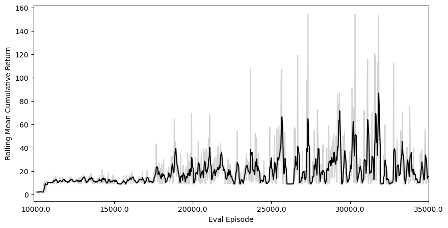

```python
eval_log_path = 'saved/ppo_image_stack_agent_log/'
evaluation_log = np.load(eval_log_path + 'evaluations.npz')
evaluation_log_df = pd.DataFrame({item: [np.mean(ep) for ep in evaluation_log[item]] for item in evaluation_log.files})
ax = evaluation_log_df.loc[0:len(evaluation_log_df), 'results'].plot(color = 'lightgray', xlim = [-5, len(evaluation_log_df)], figsize = (10,5))
evaluation_log_df['results'].rolling(5).mean().plot(color = 'black', xlim = [-5, len(evaluation_log_df)])
ax.set_xticklabels(evaluation_log_df['timesteps'])
ax.set_xlabel("Eval Episode")
plt.ylabel("Rolling Mean Cumulative Return")
plt.show()
```

It should also be noted that PPO agent performs worse than DQN agent in this case.

#### Deploy and Testing

Here, we deploy and test the fullying trained (5 million steps) agent. You can find the snapshot in saved folder.

```python
# create test environment
test_env = gym.make("FlappyBird-rgb-v0", render_mode='human')
# limit the max number of steps in an episode so that the bird won't fly forever
test_env = gym.wrappers.TimeLimit(test_env, max_episode_steps=3000)
# resize observation to (64, 128)
test_env = gym.wrappers.resize_observation.ResizeObservation(test_env, (64, 128))
test_env = gym.wrappers.gray_scale_observation.GrayScaleObservation(
    test_env, keep_dim=True
)
test_env = sb3.common.vec_env.DummyVecEnv([lambda: test_env])
test_env = sb3.common.vec_env.VecFrameStack(test_env, n_stack=4)
```

```python
# load fully trained (5,000,000 steps) agent
agent = sb3.PPO.load("saved/ppo_image_stack_agent_log/best_model.zip")
```

```python
# put agent into test environment
agent.set_env(test_env)
```

```python
mean_reward, std_reward = sb3.common.evaluation.evaluate_policy(
    agent, test_env, n_eval_episodes=30, render=False
)
print("Mean Reward: {} +/- {}".format(mean_reward, std_reward))
```

```
Mean Reward: 145.07666840478777 +/- 106.7452327831945
```

Render the agent. You can repeat by running the following cell for multiple times.

```python
obs = test_env.reset()
agent.set_env(test_env)
terminate = False
done = False
while not terminate:
    action, _ = agent.predict(obs, deterministic=True)
    obs, reward, terminate, info = test_env.step(action)
    test_env.render()
    time.sleep(1 / 30)  # FPS
```

## 3. Reflection

In this submission, we trained two types of agents with respect to both vector observation and image stack observation, respectively. The metric used to measure the performance of each trained agent is cumulative reward. We trained the four agents for 5 million steps and tested them. The results are as follows:

**vector based agent:**

DQN Agent:

Mean Reward: 19.226666934788227 +/- 7.694757324374842

PPO Agent:

Mean Reward: 17.516666914771 +/- 7.014845451510857

**image stack based agent:**

DQN Agent:

Mean Reward: 231.0266694088777 +/- 133.83539781057965

PPO Agent:

Mean Reward: 145.07666840478777 +/- 106.7452327831945

### compare vector observation with image stack observation

By comparing two different types of observations, we have drawn several conclusions:

1. The image stack based agent outperformed the vector based agent, as expected. This is due to the richer information captured in the image stacks, which provide a more detailed representation of the game state.
2. The vector based agent, while not as effective as the image stack based agent, still demonstrated a reasonable ability to navigate the game. This indicates that the essential game mechanics can be learned and approximated from simple vector representations, but with lower overall performance.
3. The image stack observation may require more computational resources than the vector based observation due to the larger input size and complexity of the images. This trade-off should be considered when designing an agent for environments where computational resources are limited.

### compare DQN agent with PPO agent

By comparing two different types of agents, we have drawn several conclusions:

1. The DQN agent performed better than the PPO agent in our experiments. This result could be attributed to the inherent differences in the learning algorithms of the two agents. DQN, being an off-policy algorithm, uses a separate target network to estimate the Q-values, which can help stabilize learning and reduce overestimations of action values.
2. The PPO agent, while not as effective as the DQN agent, still managed to achieve reasonable performance. As an on-policy algorithm, PPO aims to strike a balance between exploration and exploitation by using a trust region optimization method. However, in the Flappy Bird environment, it appears that the DQN's learning algorithm was more suitable for the task.
3. It is possible that the performance difference between the DQN and PPO agents might be due to the choice of hyperparameters and network architectures. Further experiments with different configurations could potentially reveal additional insights and enhance the performance of both algorithms.
4. The DQN agent's success could also be related to the nature of the Flappy Bird environment, which is a discrete action space problem. DQN is generally known to be better suited for discrete action spaces, while PPO tends to work better in continuous action spaces.